# ggplot2_solutions_chapter7

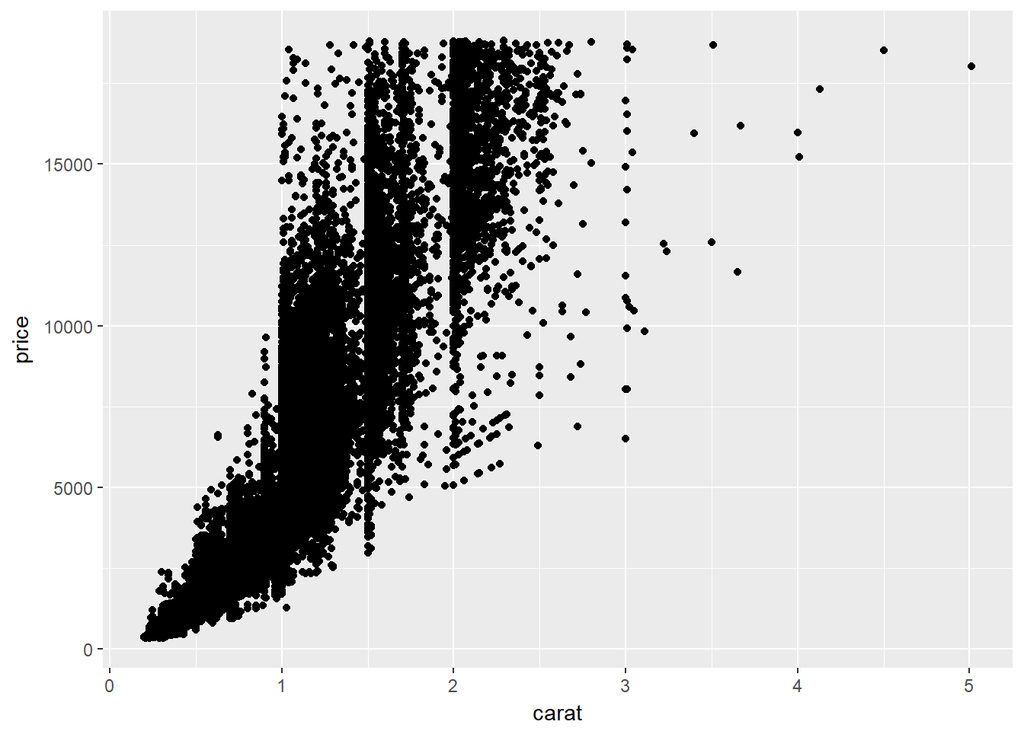

```r
base_carat <- ggplot(diamonds, aes(carat, price))
base_carat +geom_point()
```

Facetting cut and group by carat

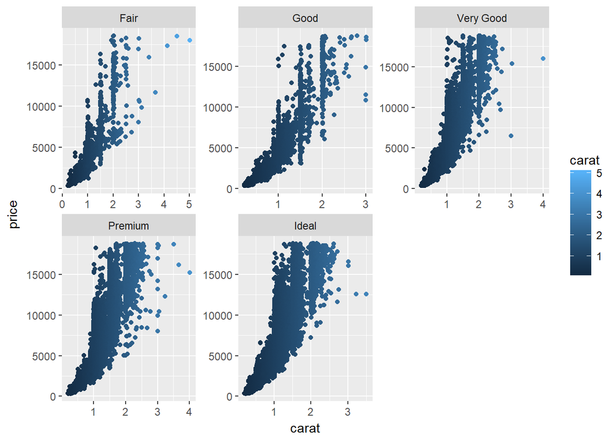

```r
base_carat + geom_point(aes(color = carat)) +
  facet_wrap(~ cut, scales = "free")
```

Try facetting by carat and grouping by cut

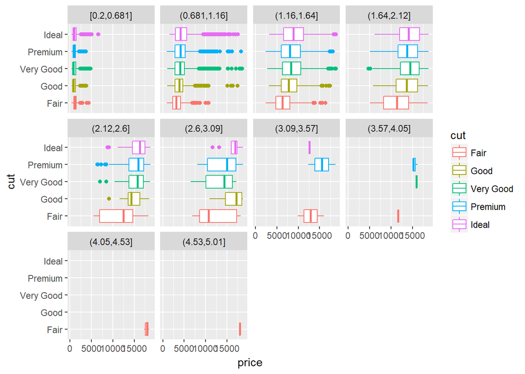

```r
diamonds2 <- diamonds
diamonds2$carat_i <- cut_interval(diamonds$carat, 10)


ggplot(diamonds, aes(cut, price)) +
  geom_boxplot(aes(color = cut)) +
  coord_flip() +
  facet_wrap(~ diamonds2$carat_i)
```

Facetting cut and group by carat is better from my point of view.

*Question 2* Diamonds: compare the relationship between price and carat for each colour. What makes it hard to compare the groups? Is grouping better or facetting? If you use facetting, what annotation might you add to make it easier to see the differences between panels?

With facetting, each group of cut is separated in its own plot, therefore, leaving no chance for us to see the differences when every cut is on the same plot. Depends on your personal taste, you can choose either faceting or grouping.

*Question 3* Why is facet wrap() generally more useful than facet grid()?

Reading from the documentation: facet_wrap wraps a 1d sequence of panels into 2d. This is generally a better use of screen space than facet_grid because most displays are roughly rectangular.

*Question 4* Recreate the following plot. It facets mpg2 by class, overlaying a smooth curve fit to the full dataset.

```r
mpg2 <- subset(mpg, cyl != 5 & drv %in% c("4", "f") & class != "2seater")
head(mpg2)
```

```
## # A tibble: 6 x 11
##   manufacturer model displ  year   cyl trans drv     cty   hwy fl    class
##   <chr>        <chr> <dbl> <int> <int> <chr> <chr> <int> <int> <chr> <chr>
## 1 audi         a4      1.8  1999     4 auto~ f        18    29 p     comp~
## 2 audi         a4      1.8  1999     4 manu~ f        21    29 p     comp~
## 3 audi         a4      2    2008     4 manu~ f        20    31 p     comp~
## 4 audi         a4      2    2008     4 auto~ f        21    30 p     comp~
## 5 audi         a4      2.8  1999     6 auto~ f        16    26 p     comp~
## 6 audi         a4      2.8  1999     6 manu~ f        18    26 p     comp~
```

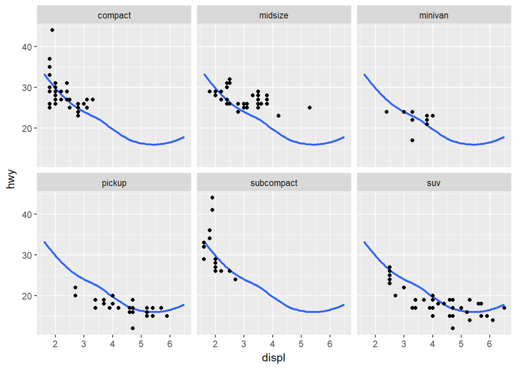

```r
ggplot(mpg2, aes(displ, hwy)) +
  geom_smooth(data = select(mpg2, -class), se = FALSE) +
  geom_point() +
  facet_wrap(~class, nrow = 2)
```

In documentation: The data to be displayed in this layer. There are three options: If NULL, the default, the data is inherited from the plot data as specified in the call to ggplot. A data.frame, or other object, will override the plot data. All objects will be fortified to produce a data frame. See fortify for which variables will be created. A function will be called with a single argument, the plot data. The return value must be a data.frame., and will be used as the layer data.